# Practical Machine Learning Assignment

Jacob Schwan

8/22/2015

# Executive Summary

This report will produce a model, using data provided by [Groupware@Les](http://groupware.les.inf.puc-rio.br/har), to predict the technique used during dumbbell exercise. The study used 4 sets of sensors to collect gyroscopic data on from the dumbell, foreare, bicep, and abdomin of the participant. 5 techniques were perfomed by each participant, 1 correct and 4 incorrect.

The random forrest technique will be used to produce a model with a high level of accuracy. The results of the model will be tested on a portion of the provided training set to estimate out of sample error. Finally the model will be used to predict the technique used for each of the 20 cases in the provided testing data set.

## Data Import & Cleaning

```r
if (!file.exists("pml-training.csv")) {
download.file(
    url="https://d396qusza40orc.cloudfront.net/predmachlearn/pml-training.csv",
    "pml-training.csv")
}
pmltraining <- read.csv("pml-training.csv", row.names=1, na.strings="#DIV/0!")
for (i in 7:158) {
    pmltraining[,i] <- as.numeric(pmltraining[,i])
}
```

## Divide Data into Training & Test Set

The provided training data is divided into a training & test set in order to later estimate the out of sample error rate.

```r
set.seed(11885)
library(caret)
inTrain <- createDataPartition(pmltraining$classe,p=0.8,list = F)
training <- pmltraining[inTrain,]
testing <- pmltraining[-inTrain,]
```

## Predictor Variable Selection

Many of the variable in the training data have NA values. Charting the number of NA values for each variable produces the following graph.

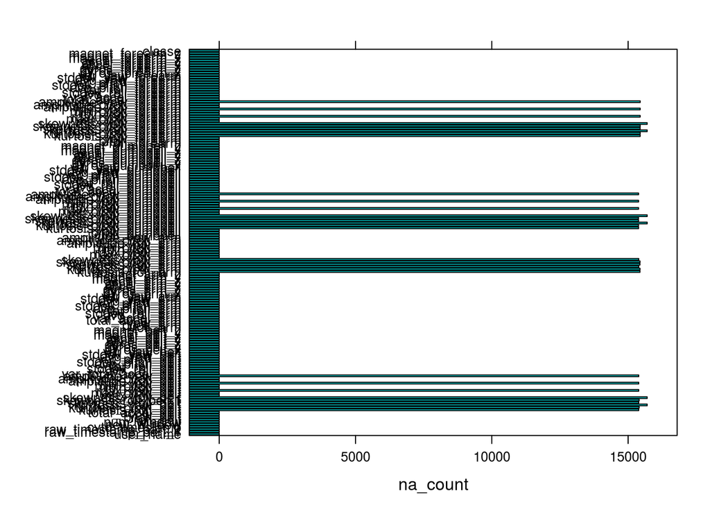

```r
na_count <- sapply(training, function(x) sum(length(which(is.na(x)))))
barchart(na_count)
```

The above graph show that variables either contain 0 NA’s or a very large percentage of the values are NA. These variables shall be removed, along with the arbitrary timestamp & window varibles.

```r
na_vars <- names(na_count[na_count!=0])
dropVars <- c("raw_timestamp_part1","raw_timestamp_part2","cvtd_timestamp",
              "num_window", na_vars)
training <- training[,!(names(training) %in% dropVars)]
```

The predictors shall be further reduced by eliminating variables with near zero variance.

```r
zeroVar <- nearZeroVar(training)
training <- training[,-zeroVar]
```

This leaves 55 prediction variable to use in modeling.

# Model

A random forrest model will be used, due to its reputation for high accuracy with categorical results. Repeated k-fold cross-validation is used in building the model. Due to the large sample size of the training data, a small number of folds & repeats can be used without much consequence. 3 folds will be used and repeated 3 times.

```r
library(doParallel)
registerDoParallel(cores=3)
fitControl <- trainControl(method = "repeatedcv", number=3, repeats = 3)
modelFitRF <- train(classe ~ ., data=training, method="rf",
                    trControl = fitControl)
errRatetrain <- as.numeric(1 - modelFitRF$result$Accuracy[2])
modelFitRF
```

```
## Random Forest
##
## 15699 samples
##    55 predictors
##     5 classes: 'A', 'B', 'C', 'D', 'E'
##
## No pre-processing
## Resampling: Cross-Validated (3 fold, repeated 3 times)
## Summary of sample sizes: 10466, 10465, 10467, 10468, 10465, 10465, ...
## Resampling results across tuning parameters:
##
##   mtry  Accuracy   Kappa      Accuracy SD  Kappa SD
##    2    0.9929294  0.9910553  0.001657930  0.002097708
##   30    0.9966241  0.9957299  0.001416768  0.001791899
##   59    0.9930354  0.9911892  0.003211723  0.004064009
##
## Accuracy was used to select the optimal model using  the largest value.
## The final value used for the model was mtry = 30.
```

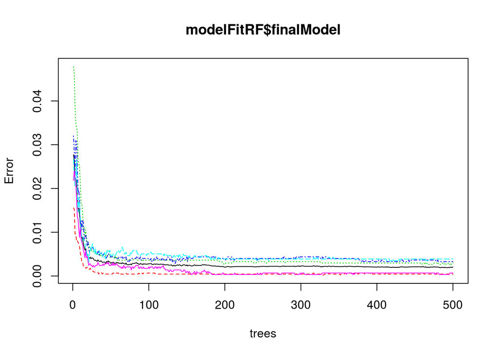

```r
plot(modelFitRF$finalModel)
```

The insample error rate of the final model selected is 0.3375926%.

## Model Testing

```r
testResults <- predict(modelFitRF,testing)
testConfMat <- confusionMatrix(testResults,testing$classe)
errRatetest <- as.numeric(1-testConfMat$overall[1])
testConfMat
```

```
## Confusion Matrix and Statistics
##
##           Reference
## Prediction    A    B    C    D    E
##          A 1115    0    0    0    0
##          B    1  759    0    0    0
##          C    0    0  684    0    0
##          D    0    0    0  643    0
##          E    0    0    0    0  721
##
## Overall Statistics
##
##                Accuracy : 0.9997
##                  95% CI : (0.9986, 1)
##     No Information Rate : 0.2845
##     P-Value [Acc > NIR] : < 2.2e-16
##
##                   Kappa : 0.9997
##  Mcnemar's Test P-Value : NA
##
## Statistics by Class:
##
##                      Class: A Class: B Class: C Class: D Class: E
## Sensitivity            0.9991   1.0000   1.0000   1.0000   1.0000
## Specificity            1.0000   0.9997   1.0000   1.0000   1.0000
## Pos Pred Value         1.0000   0.9987   1.0000   1.0000   1.0000
## Neg Pred Value         0.9996   1.0000   1.0000   1.0000   1.0000
## Prevalence             0.2845   0.1935   0.1744   0.1639   0.1838
## Detection Rate         0.2842   0.1935   0.1744   0.1639   0.1838
## Detection Prevalence   0.2842   0.1937   0.1744   0.1639   0.1838
## Balanced Accuracy      0.9996   0.9998   1.0000   1.0000   1.0000
```

The above confustion matrix show the resluts of our model predictions. With an error rate of 0.0254907%, the estimated out of sample error is smaller than the insample error.

# Submission Test

Finally, the above model will be used to predict answers on the provided testing data for the submission assignment.

```r
if (!file.exists("pml-training.csv")) {
download.file(
    url="https://d396qusza40orc.cloudfront.net/predmachlearn/pml-testing.csv",
    "pml-testing.csv")
}
pmltesting <- read.csv("pml-testing.csv", row.names=1, na.strings="#DIV/0!")
for (i in 7:158) {
    pmltesting[,i] <- as.numeric(pmltesting[,i])
}
finalTest <- predict(modelFitRF,pmltesting)
finalTest
```

```
##  [1] B A B A A E D B A A B C B A E E A B B B
## Levels: A B C D E
```

The above predictions resulted in 100% accuracy when submitted.